# Data 605 HW1

Mubashira Qari

2024-01-27

One of the most useful applications for linear algebra in data science is image manipulation. We often need to compress, expand, warp, skew, etc. images. To do so, we left multiply a transformation matrix by each of the point vectors.  
For this assignment, build the first letters for both your first and last name using point plots in R. For example, the following code builds an H. x=c(rep(0,500),seq(0,1,length.out=1000), rep(1,500)) y=c(seq(-1,1,length.out=500),rep(0,1000), seq(-1,1,length.out=500)) z=rbind(x,y) plot(y~x, xlim=c(-3,3), ylim=c(-3,3)) Then, write R code that will left multiply (%*%) a square matrix (x) against each of the vectors of points (y). Initially, that square matrix will be the Identity matrix.  
Use a loop that changes the transformation matrix incrementally to demonstrate 1) shear, 2) scaling, 3) rotation , and 4) projection in animated fashion.  
Hint: Use x11() to open a new plotting window in R.

```r
library(dplyr)
```

```r
library(plotly)
library(gifski)
library(anim.plots)
```

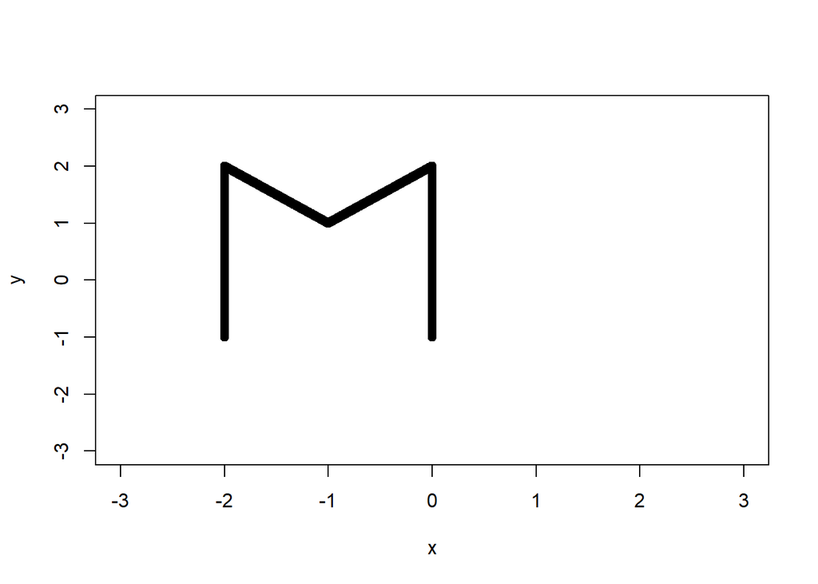

```r
# Plotting M
x=c(rep(-2,1000),seq(-2,-1,length.out=500), seq(-1,0,length.out=500), rep(0,1000))
y=c(seq(-1,2,length.out=1000),seq(2, 1,length.out=500), seq(1, 2,length.out=500), seq(2,-1,length.out=1000))
z=rbind(x,y)
plot(y~x, xlim=c(-3,3), ylim=c(-3,3))
```

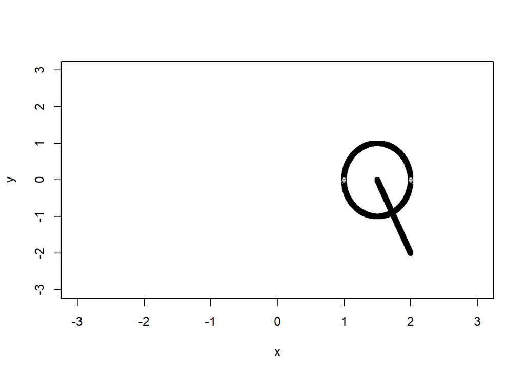

```r
# Plotting Q
x=c(seq(1,2,length.out = 500), seq(1,2,length.out = 500), seq(1.5,2,length.out=1000))
y=c(sqrt(1-(seq(0,2.0,length.out = 500)-1)^2), -sqrt(1-(seq(0,2.0,length.out = 500)-1)^2),seq(0,-2,length.out=1000))
z=rbind(x,y)
plot(y~x, xlim=c(-3,3), ylim=c(-3,3))
```

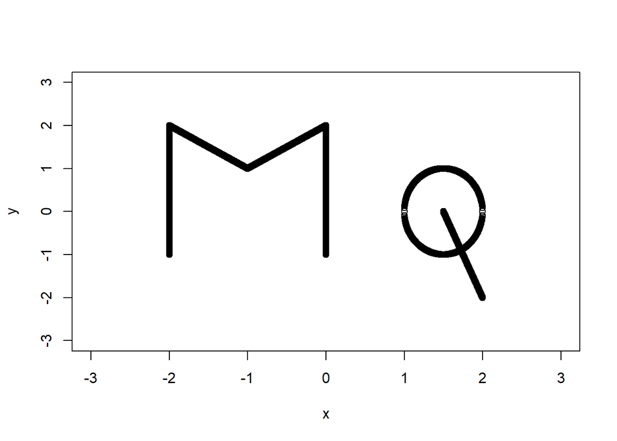

```r
# Plotting MQ

x=c(rep(-2,1000),seq(-2,-1,length.out=500), seq(-1,0,length.out=500), rep(0,1000), seq(1,2,length.out = 500), seq(1,2,length.out = 500), seq(1.5,2,length.out=1000))
y=c(seq(-1,2,length.out=1000),seq(2, 1,length.out=500), seq(1, 2,length.out=500), seq(2,-1,length.out=1000), sqrt(1-(seq(0,2.0,length.out = 500)-1)^2), -sqrt(1-(seq(0,2.0,length.out = 500)-1)^2),seq(0,-2,length.out=1000))
z=rbind(x,y)
plot(y~x, xlim=c(-3,3), ylim=c(-3,3))
```

```r
# matrix from the x and y coordinates
coord_matrix = matrix(c(x, y), ncol=2)
```

```r
# Identity matrix plug in with k to convert to scaling matrix
k <- 3
identity_matrix <- matrix(c(k, 0, 0, k), ncol=2)
scale_matrix <- identity_matrix
scale_matrix
```

```
##      [,1] [,2]
## [1,]    3    0
## [2,]    0    3
```

### R code that will left multiply (%>%) a square matrix (x) against each of the vectors of points (y).

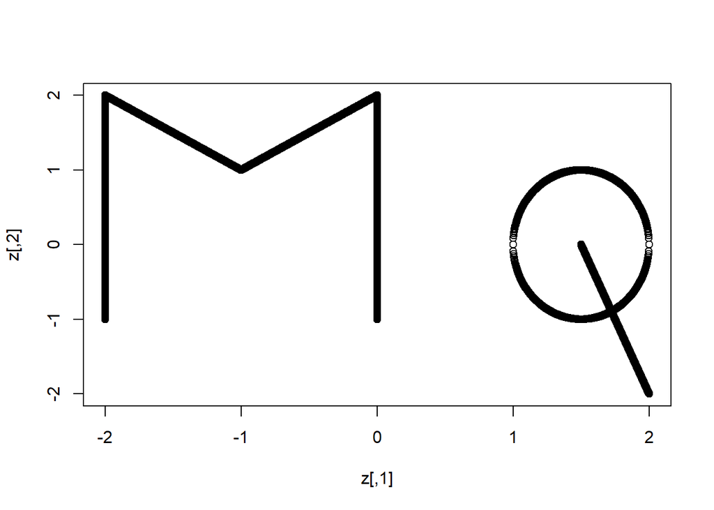

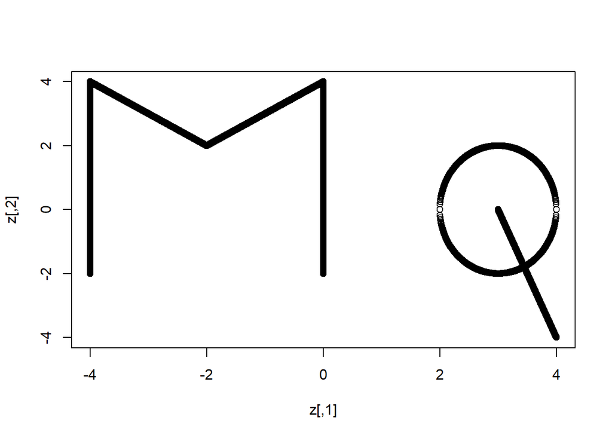

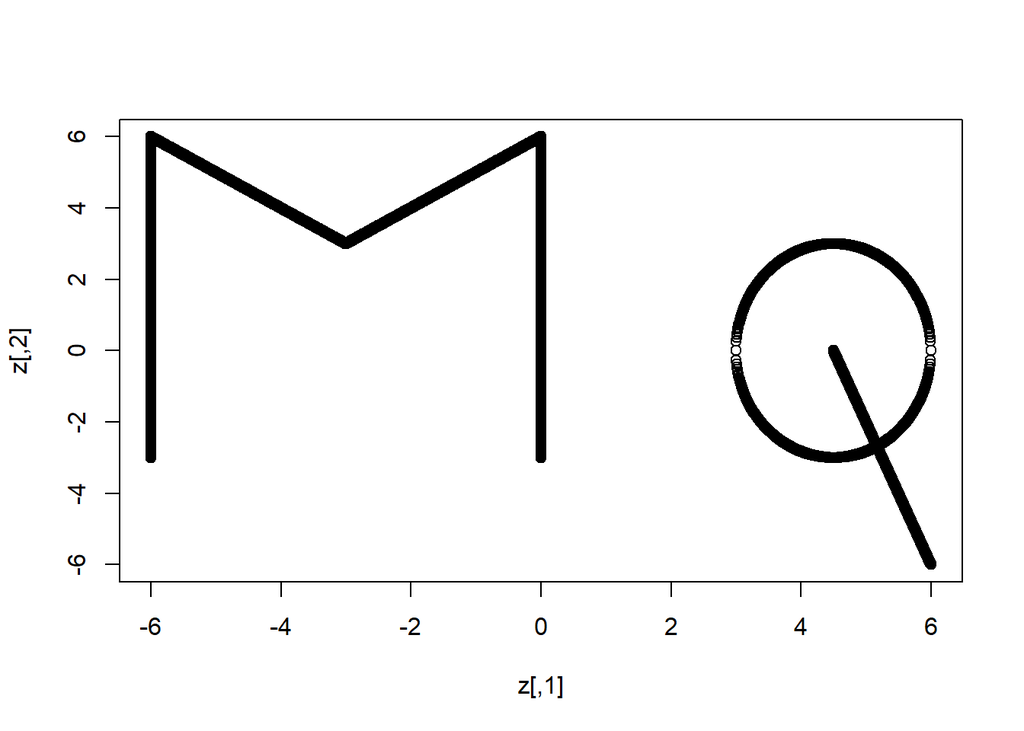

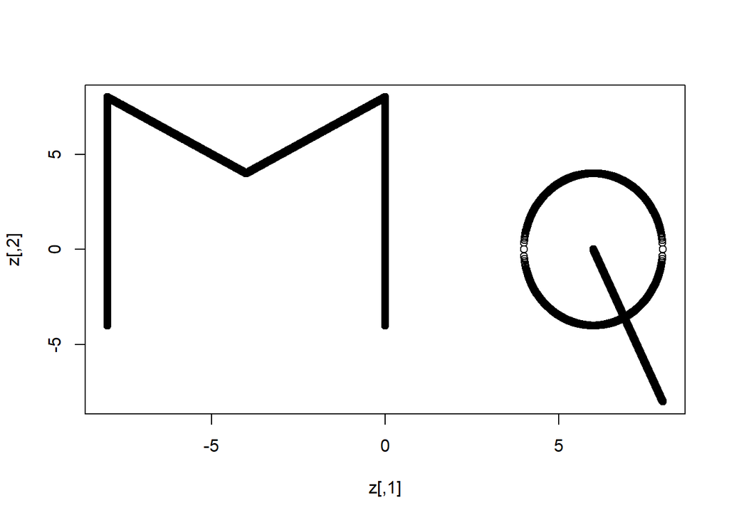

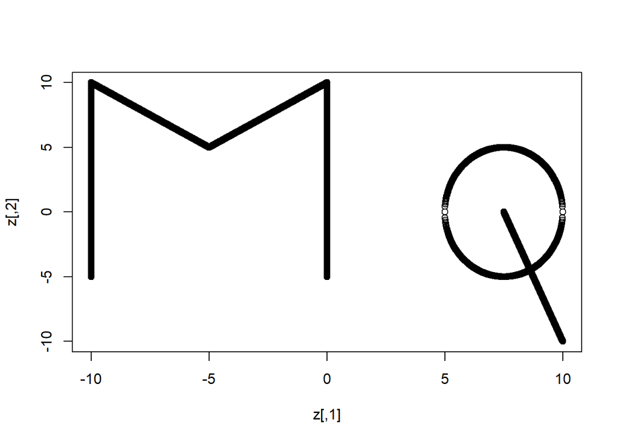

```r
for (k in 1:5) {
identity_matrix <- matrix(c(k, 0, 0, k), ncol=2)
scale_matrix <- identity_matrix
transformed_matrix_scale= coord_matrix %*% scale_matrix
z<-transformed_matrix_scale
plot(z)
}
```

### Shear